# Overview

This notebook performs a comprehensive analysis to predict PAM50 breast cancer subtypes with supervised ML using gene expression data. The main steps are:

1. **Data Loading & Preprocessing**
   - Expression and clinical data are loaded from CSV files.
   - Samples are aligned between datasets.
   - The multiclass target variable (PAM50 subtypes) is extracted and label-encoded.
2. **Model Training & Evaluation**
   - Logistic Regression is trained to predict subtypes using both z-scored and raw (collapsed) expression data.
   - Performance is evaluated using classification reports and confusion matrices.
   - The raw (non-zscored) data performs better and is used for further analysis.
3. **Feature Importance**
   - Top features per class are visualized using model coefficients.
   - SHAP (SHapley Additive exPlanations) values are computed for the best Logistic Regression model to interpret feature contributions.
4. **Hyperparameter Tuning**
   - Grid search is performed for Logistic Regression, Random Forest, and SVC to optimize model parameters.
   - Best models are evaluated on the test set.
5. **SHAP Analysis**
   - SHAP summary plots are generated for each class to visualize important genes.
   - Genes with high SHAP values across multiple classes are identified.

This workflow provides both predictive performance and biological interpretability for cancer subtype classification.

# Imports

```python
import os
from pathlib import Path
import numpy as np
import pandas as pd
from dotenv import load_dotenv
from sklearn.model_selection import train_test_split, GridSearchCV
from sklearn.linear_model import LogisticRegression
from sklearn.ensemble import RandomForestClassifier
from sklearn.svm import SVC
from sklearn.metrics import classification_report, confusion_matrix
from sklearn.preprocessing import LabelEncoder
import shap
import math

import matplotlib.pyplot as plt
```

# Prediction of Subtypes with Zscored

```python
load_dotenv(dotenv_path="/Users/sarah/Code/bioinformatics-tool/analysis/.env")

def find_repo_root(start_path: Path = None) -> Path:
    if start_path is None:
        start_path = Path().resolve()
    for parent in [start_path] + list(start_path.parents):
        if (parent / '.git').exists():
            return parent
    raise RuntimeError("Could not find repo root!")

repo_root = find_repo_root()
print(repo_root)

expression_path = repo_root / os.getenv("ZSCORED_QUALITY_CHECKED")
clinical_path = repo_root / os.getenv("CLINICAL_IMPUTED")

expression = pd.read_csv(expression_path, index_col=0)
clinical = pd.read_csv(clinical_path, index_col=0)

# Align samples
common_samples = expression.index.intersection(clinical.index)
X = expression.loc[common_samples]
clinical = clinical.loc[common_samples]

# Multiclass target: PAM50 subtypes
pam50_col = [col for col in clinical.columns if "pam50" in col.lower()][0]
label_encoder = LabelEncoder()
y = label_encoder.fit_transform(clinical[pam50_col].astype(str))
class_names = label_encoder.classes_

# Split data
X_train, X_test, y_train, y_test = train_test_split(X, y, stratify=y, test_size=0.2, random_state=42)

# Train classifier
clf = LogisticRegression(max_iter=1000, class_weight="balanced", multi_class="multinomial")
clf.fit(X_train, y_train)

# Predict and evaluate
y_pred = clf.predict(X_test)
print(classification_report(y_test, y_pred, target_names=class_names))
print("Confusion matrix:\n", confusion_matrix(y_test, y_pred))
```

```
/Users/sarah/Code/bioinformatics-tool
```

```
              precision    recall  f1-score   support

       Basal       0.90      0.94      0.92        68
        Her2       0.85      0.86      0.85        65
        LumA       0.92      0.92      0.92       332
        LumB       0.84      0.90      0.87       146
      Normal       0.84      0.59      0.69        44

    accuracy                           0.89       655
   macro avg       0.87      0.84      0.85       655
weighted avg       0.89      0.89      0.89       655

Confusion matrix:
 [[ 64   1   0   1   2]
 [  2  56   2   4   1]
 [  1   4 306  19   2]
 [  0   1  14 131   0]
 [  4   4   9   1  26]]
```

# Prediction of Subtypes using Collapsed (non-zscored)

To compare to the Z-scored, I try predicting the cancer subtypes using the collapsed dataset that was not z-scored, because this could be better since raw expression values might keep more biologically meaningful differences.

```python
expression_path = repo_root / os.getenv("EM_COLLAPSED")
clinical_path = repo_root / os.getenv("CLINICAL_IMPUTED")

expression = pd.read_csv(expression_path, index_col=0)
clinical = pd.read_csv(clinical_path, index_col=0)

# Align samples
common_samples = expression.index.intersection(clinical.index)
X = expression.loc[common_samples]
clinical = clinical.loc[common_samples]

# Multiclass target: PAM50 subtypes
pam50_col = [col for col in clinical.columns if "pam50" in col.lower()][0]
label_encoder = LabelEncoder()
y = label_encoder.fit_transform(clinical[pam50_col].astype(str))
class_names = label_encoder.classes_

# Split data
X_train, X_test, y_train, y_test = train_test_split(X, y, stratify=y, test_size=0.2, random_state=42)

# Train classifier
clf = LogisticRegression(max_iter=1000, class_weight="balanced", multi_class="multinomial")
clf.fit(X_train, y_train)

# Predict and evaluate
y_pred = clf.predict(X_test)
print(classification_report(y_test, y_pred, target_names=class_names))
print("Confusion matrix:\n", confusion_matrix(y_test, y_pred))
```

```
              precision    recall  f1-score   support

       Basal       0.91      0.94      0.93        68
        Her2       0.89      0.86      0.88        65
        LumA       0.92      0.92      0.92       332
        LumB       0.87      0.90      0.88       146
      Normal       0.76      0.66      0.71        44

    accuracy                           0.90       655
   macro avg       0.87      0.86      0.86       655
weighted avg       0.90      0.90      0.90       655

Confusion matrix:
 [[ 64   1   0   0   3]
 [  2  56   2   3   2]
 [  0   4 307  17   4]
 [  0   2  13 131   0]
 [  4   0  11   0  29]]
```

As we can see, the non-zscored performs a bit better, so I continue with that one.

## Feature Importance

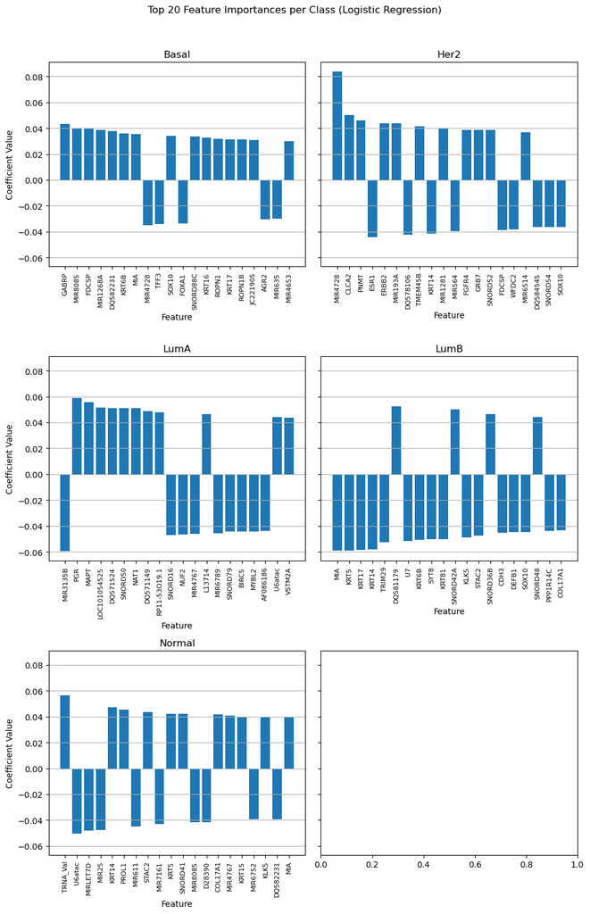

```python
lr_model = clf
coefs = lr_model.coef_  # shape: (n_classes, n_features)

top_n = 20  # Show top 20 features per class
feature_names = X.columns

n_classes = len(class_names)
n_cols = 2
n_rows = math.ceil(n_classes / n_cols)
fig, axes = plt.subplots(n_rows, n_cols, figsize=(5 * n_cols, 5 * n_rows), sharey=True)

for i, class_name in enumerate(class_names):
    row, col = divmod(i, n_cols)
    ax = axes[row, col] if n_rows > 1 else axes[col]
    coef_abs = np.abs(coefs[i])
    indices = np.argsort(coef_abs)[::-1][:top_n]
    ax.bar(range(top_n), coefs[i][indices], align="center")
    ax.set_title(f"{class_name}")
    ax.set_xticks(range(top_n))
    ax.set_xticklabels(feature_names[indices], rotation=90, fontsize=8)
    ax.set_ylabel("Coefficient Value" if col == 0 else "")
    ax.set_xlabel("Feature")
    ax.grid(True, axis='y')


fig.suptitle(f"Top {top_n} Feature Importances per Class (Logistic Regression)", y=1.02)
plt.tight_layout()
plt.show()
```

## SHAP Summary Plot

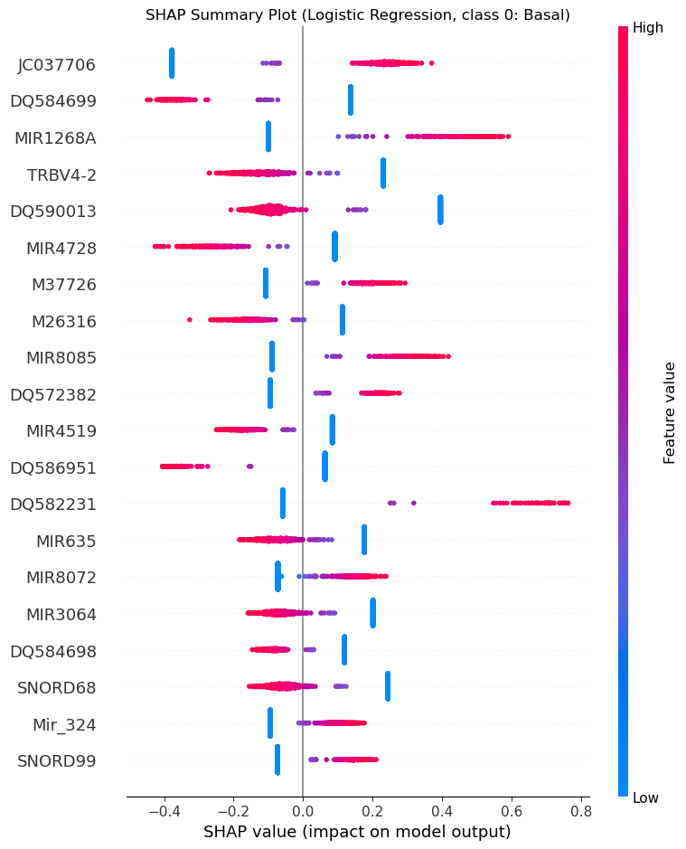

```python
explainer = shap.Explainer(lr_model, X_train)
shap_values = explainer(X_test)

# For multiclass, plot for each class (here: class 0)
plt.title(f"SHAP Summary Plot (Logistic Regression, class 0: {class_names[0]})")
shap.summary_plot(shap_values[..., 0], X_test, feature_names=feature_names)
```

## Grid Search & Hyperparameter Tuning

```python
expression_path = repo_root / os.getenv("EM_COLLAPSED")
clinical_path = repo_root / os.getenv("CLINICAL_IMPUTED")

expression = pd.read_csv(expression_path, index_col=0)
clinical = pd.read_csv(clinical_path, index_col=0)

# Align samples
common_samples = expression.index.intersection(clinical.index)
X = expression.loc[common_samples]
clinical = clinical.loc[common_samples]

# Multiclass target: PAM50 subtypes
pam50_col = [col for col in clinical.columns if "pam50" in col.lower()][0]
label_encoder = LabelEncoder()
y = label_encoder.fit_transform(clinical[pam50_col].astype(str))
class_names = label_encoder.classes_

# Split data
X_train, X_test, y_train, y_test = train_test_split(X, y, stratify=y, test_size=0.2, random_state=42)

# Define models and parameter grids
models_and_params = {
    "LogisticRegression": (
        LogisticRegression(class_weight="balanced", max_iter=1000),
        {
            "C": [1, 10],
            "solver": ["lbfgs"]
        }
    ),
    "RandomForest": (
        RandomForestClassifier(class_weight="balanced", random_state=42),
        {
            "n_estimators": [50, 100],
            "max_depth": [None, 10]
        }
    ),
    "SVC": (
        SVC(class_weight="balanced", probability=True, random_state=42),
        {
            "C": [1],
            "kernel": ["linear"]
        }
    )
}

best_models = {}
for name, (model, param_grid) in models_and_params.items():
    print(f"\nGrid search for {name}...")
    grid = GridSearchCV(model, param_grid, cv=5, scoring="accuracy", n_jobs=-1)
    grid.fit(X_train, y_train)
    print(f"Best params: {grid.best_params_}")
    print(f"Best CV accuracy: {grid.best_score_:.3f}")
    best_models[name] = grid.best_estimator_

# Evaluate best models on test set
for name, model in best_models.items():
    y_pred = model.predict(X_test)
    print(f"\n{name} test set classification report:")
    print(classification_report(y_test, y_pred, target_names=class_names))
    print("Confusion matrix:\n", confusion_matrix(y_test, y_pred))
```

```
Grid search for LogisticRegression...
Best params: {'C': 1, 'solver': 'lbfgs'}
Best CV accuracy: 0.879

Grid search for RandomForest...
Best params: {'max_depth': 10, 'n_estimators': 100}
Best CV accuracy: 0.856

Grid search for SVC...
Best params: {'C': 1, 'kernel': 'linear'}
Best CV accuracy: 0.872

LogisticRegression test set classification report:
              precision    recall  f1-score   support

       Basal       0.91      0.94      0.93        68
        Her2       0.89      0.86      0.88        65
        LumA       0.92      0.92      0.92       332
        LumB       0.87      0.90      0.88       146
      Normal       0.76      0.66      0.71        44

    accuracy                           0.90       655
   macro avg       0.87      0.86      0.86       655
weighted avg       0.90      0.90      0.90       655

Confusion matrix:
 [[ 64   1   0   0   3]
 [  2  56   2   3   2]
 [  0   4 307  17   4]
 [  0   2  13 131   0]
 [  4   0  11   0  29]]

RandomForest test set classification report:
              precision    recall  f1-score   support

       Basal       0.93      0.91      0.92        68
        Her2       0.93      0.80      0.86        65
        LumA       0.88      0.92      0.90       332
        LumB       0.84      0.88      0.86       146
      Normal       0.67      0.50      0.57        44
```

[output cut: 16 more lines]

```
        Her2       0.84      0.88      0.86        65
        LumA       0.90      0.92      0.91       332
        LumB       0.87      0.88      0.87       146
      Normal       0.75      0.55      0.63        44

    accuracy                           0.88       655
   macro avg       0.86      0.83      0.84       655
weighted avg       0.88      0.88      0.88       655

Confusion matrix:
 [[ 63   2   0   0   3]
 [  1  57   3   3   1]
 [  0   6 306  16   4]
 [  0   2  16 128   0]
 [  4   1  15   0  24]]
```

### Grid Search Best Logistic Regression

```
Best Logistic Regression params: {'C': 1, 'class_weight': 'balanced', 'max_iter': 1000, 'solver': 'lbfgs'}
Classification report:
               precision    recall  f1-score   support

       Basal       0.91      0.94      0.93        68
        Her2       0.89      0.86      0.88        65
        LumA       0.92      0.92      0.92       332
        LumB       0.87      0.90      0.88       146
      Normal       0.76      0.66      0.71        44

    accuracy                           0.90       655
   macro avg       0.87      0.86      0.86       655
weighted avg       0.90      0.90      0.90       655
```

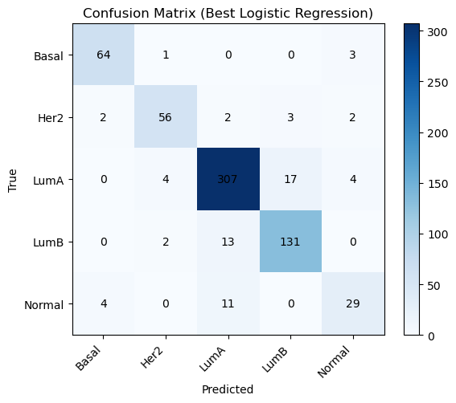

```python
# Grid search for Logistic Regression
param_grid_lr = {
    "C": [0.1, 1, 10],
    "solver": ["lbfgs"],
    "max_iter": [1000],
    "class_weight": ["balanced"],
}
grid_lr = GridSearchCV(LogisticRegression(), param_grid_lr, cv=5, scoring="accuracy", n_jobs=-1)
grid_lr.fit(X_train, y_train)

best_lr = grid_lr.best_estimator_
y_pred_lr = best_lr.predict(X_test)

print("Best Logistic Regression params:", grid_lr.best_params_)
print("Classification report:\n", classification_report(y_test, y_pred_lr, target_names=class_names))

# Confusion matrix plot
cm = confusion_matrix(y_test, y_pred_lr)
fig_cm, ax_cm = plt.subplots(figsize=(6, 5))
im = ax_cm.imshow(cm, cmap="Blues")
ax_cm.set_xticks(np.arange(len(class_names)))
ax_cm.set_yticks(np.arange(len(class_names)))
ax_cm.set_xticklabels(class_names, rotation=45, ha="right")
ax_cm.set_yticklabels(class_names)
plt.xlabel("Predicted")
plt.ylabel("True")
plt.title("Confusion Matrix (Best Logistic Regression)")
plt.colorbar(im, ax=ax_cm)
for i in range(len(class_names)):
    for j in range(len(class_names)):
        ax_cm.text(j, i, cm[i, j], ha="center", va="center", color="black")
plt.tight_layout()
plt.show()
```

```python
grid_lr.best_params_
```

```
{'C': 1, 'class_weight': 'balanced', 'max_iter': 1000, 'solver': 'lbfgs'}
```

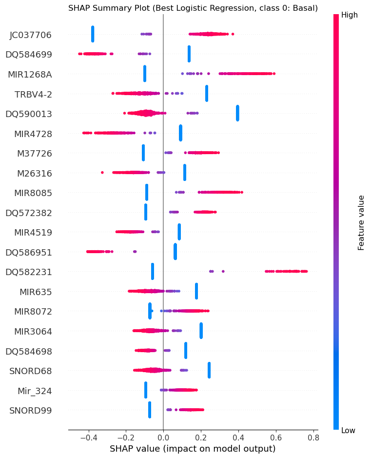

```python
import shap

explainer_best = shap.Explainer(best_lr, X_train)
shap_values_best = explainer_best(X_test)

plt.title(f"SHAP Summary Plot (Best Logistic Regression, class 0: {class_names[0]})")
shap.summary_plot(shap_values_best[..., 0], X_test, feature_names=X.columns)
```

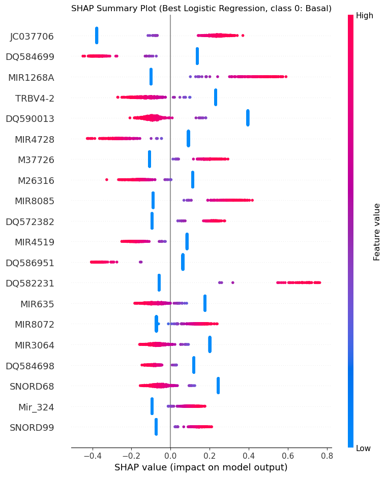

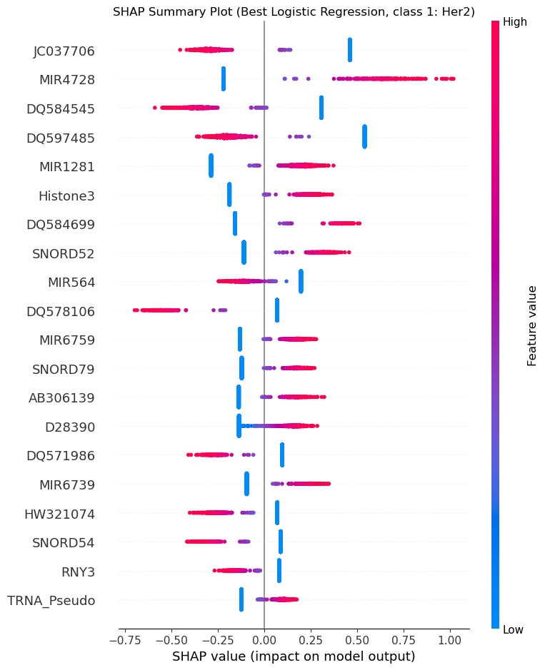

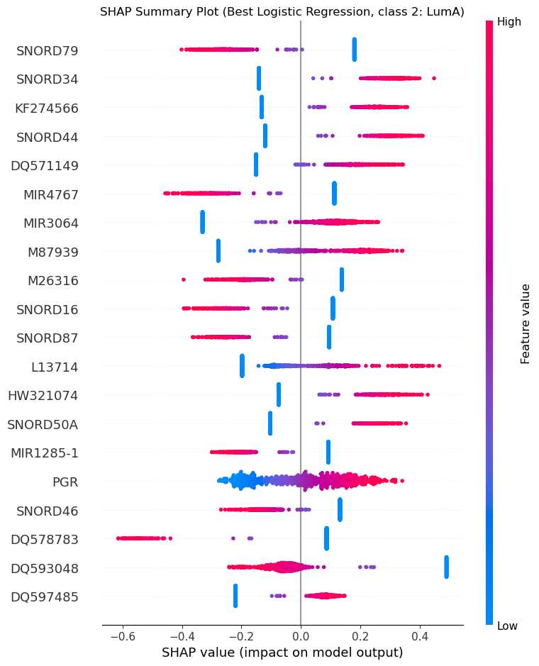

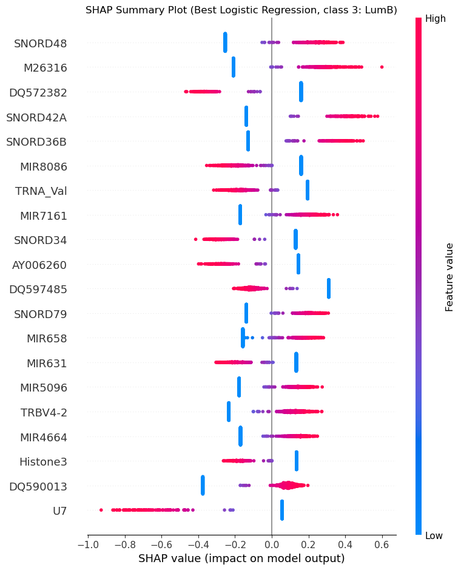

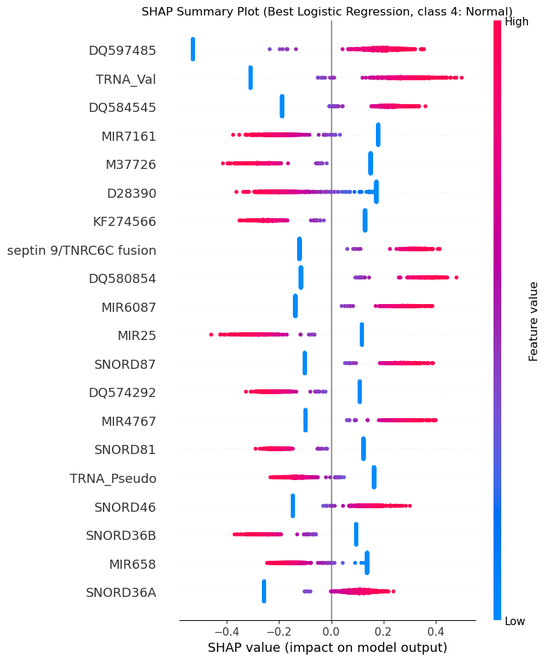

```python
for class_idx, class_name in enumerate(class_names):
    plt.title(f"SHAP Summary Plot (Best Logistic Regression, class {class_idx}: {class_name})")
    shap.summary_plot(shap_values_best[..., class_idx], X_test, feature_names=X.columns, show=True)
```

```python
# Calculate mean absolute SHAP values for each feature and class
mean_abs_shap_per_class = np.abs(shap_values_best.values).mean(axis=0)  # shape: (n_features, n_classes)
feature_names = expression.columns

# For each feature, find the classes where it is among the top SHAP values
top_n = 10
high_shap_features = {}

for class_idx in range(mean_abs_shap_per_class.shape[1]):
    top_indices = np.argsort(mean_abs_shap_per_class[:, class_idx])[::-1][:top_n]
    for idx in top_indices:
        gene = feature_names[idx]
        high_shap_features.setdefault(gene, set()).add(class_idx)

# Find genes that appear in top_n for more than one class
multi_class_genes = {gene: classes for gene, classes in high_shap_features.items() if len(classes) > 1}

print("Genes with high SHAP values for multiple classes:")
for gene, classes in multi_class_genes.items():
    print(f"{gene}: classes {sorted(classes)}")
```

```
Genes with high SHAP values for multiple classes:
JC037706: classes [0, 1]
DQ584699: classes [0, 1]
MIR4728: classes [0, 1]
M37726: classes [0, 4]
M26316: classes [0, 2, 3]
DQ572382: classes [0, 3]
DQ584545: classes [1, 4]
DQ597485: classes [1, 4]
SNORD34: classes [2, 3]
KF274566: classes [2, 4]
TRNA_Val: classes [3, 4]
MIR7161: classes [3, 4]
```

# Summary of Results

- **Data Loading & Preprocessing:**  
  Gene expression and clinical data were loaded and aligned. The PAM50 breast cancer subtypes were extracted and label-encoded for supervised classification.
- **Model Comparison:**  
  Logistic Regression models were trained on both z-scored and raw (collapsed) expression data. The model using raw data performed better, so subsequent analyses focused on this dataset.
- **Feature Importance:**  
  Top genes contributing to each subtype were identified using Logistic Regression coefficients. Several genes showed strong importance for specific classes.
- **SHAP Analysis:**  
  SHAP values provided interpretability for the best Logistic Regression model. Summary plots highlighted the most influential genes per class. Some genes (e.g., JC037706, DQ584699, MIR4728, M37726, M26316, DQ572382, DQ584545, DQ597485, SNORD34, KF274566, TRNA_Val, MIR7161) were important for multiple subtypes.
- **Hyperparameter Tuning:**  
  Grid search was performed for Logistic Regression, Random Forest, and SVC. The best Logistic Regression model achieved the highest test accuracy and balanced performance across classes.
- **Confusion Matrix & Classification Report:**  
  The best model showed good predictive accuracy for most subtypes, with some confusion between closely related classes (especially Luminal A and Luminal B).
- **Biological Insights:**  
  Genes with high SHAP values across multiple classes may play broader roles in breast cancer biology and could be candidates for further investigation.

Overall, the workflow provided robust subtype prediction and interpretable gene-level insights for breast cancer classification.